# QMSS Data Visualization

TA Session 2: Continuing with ggplot2 Package

Yifei Dong

1/25/2021

```r
# Load required packages
library(tidyverse)
library(ggthemes)
library(scales)
library(RColorBrewer)
```

#### 2.3 Advanced Bar Chart

Suppose you want to add specific percent information into your proportional barplot. There are multiple ways to handle this task. But ideas are very similar, you create a basic bar chart (either stack or dodge) and then add more layers into your plot. If you want to mark additional information, you should consider use `geom_text` function or `geom_label` function.

**Question**: Please show Respondents’ Party Affiliation by Regions.

Again, I will be working with some data from the Cooperative Congressional Election Study, a major academic survey about American politics. Here, I am using a random sample (1000 respondents) of this data from 2019 study. Also, I modified the dataset a lot to remove many survey questions. So, if want to do real analysis with dataset, you should download original data files, as well as code books from the CCES website (Ansolabehere, Schaffner, and Luks 2020).

```r
cces <- read_csv("../data/cces_sample.csv")
glimpse(cces)
```

[output not shown]

- First, recode the data for “pid7” variable and generate a new variable “party,” which indicates the party affiliation, respondent with 1, 2, 3 are coded as “Democrat,” respondent with 4 are coded as “Independent,” and respondent with 5, 6, 7 are coded as “Republican.” This should be a categorical variable. Here, I use `recode_factor` command in `dplyr` package.
- recode the “region” variable into a factor as well.
- create a “summary” statistics for each of the region.
- Generate a Bar plot, use `facet` command to split your plot into multiple panels.
- Add text annotations to those bars so that readers know the specific numbers, additional packages required: `scales`.
- customize your plot, adding titles, subtitles (if necessary), caption, as well as changing colors, axes scales.

```r
cces$party <- recode_factor(cces$pid7,
                            `1` = "Democrat",
                            `2` = "Democrat",
                            `3` = "Democrat",
                            `4` = "Independent",
                            `5` = "Republican",
                            `6` = "Republican",
                            `7` = "Republican")
cces$region <- recode_factor(cces$region,
                             `1` = "Northwest",
                             `2` = "Midwest",
                             `3` = "South",
                             `4` = "West")
```

```r
summary <- cces %>%
  dplyr::select(region, party) %>%
  group_by(region, party) %>%
  tally() %>%
  mutate(prop = n/sum(n)) %>%
  ungroup()
summary
```

```
## # A tibble: 12 x 4
##    region    party           n  prop
##    <fct>     <fct>       <int> <dbl>
##  1 Northwest Democrat      102 0.537
##  2 Northwest Independent    26 0.137
##  3 Northwest Republican     62 0.326
##  4 Midwest   Democrat      124 0.551
##  5 Midwest   Independent    23 0.102
##  6 Midwest   Republican     78 0.347
##  7 South     Democrat      178 0.458
##  8 South     Independent    46 0.118
##  9 South     Republican    165 0.424
## 10 West      Democrat      112 0.571
## 11 West      Independent    24 0.122
## 12 West      Republican     60 0.306
```

Now, we have all required data. Let’s start plotting.

**Example**: Stacked Bar Chart

We can simply use stacked bar chart to show the distribution first. Each region consists three different categories and they should add up to 1. So, the x-axis is `region`, and y-axis is `prop`.

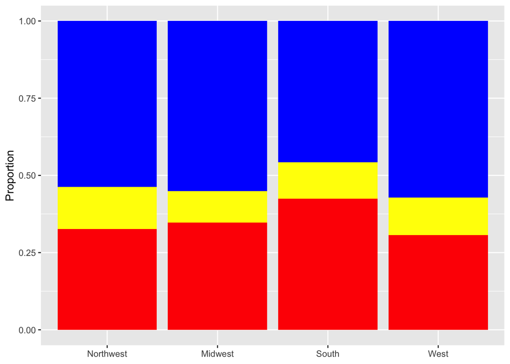

```r
summary %>%
  ggplot(aes(x = region, y = prop, fill = party))+
  geom_bar(stat = "identity",
           show.legend = FALSE)+
  scale_fill_manual(values = c("blue", "yellow", "red"),
                    breaks = c("Democrat", "Independent", "Republican"))+
  scale_y_continuous("Proportion")+
  theme(axis.title.x = element_blank())
```

**Example**: Dodged Bar Chart

Sometimes it may be better to use dodged bar chart.

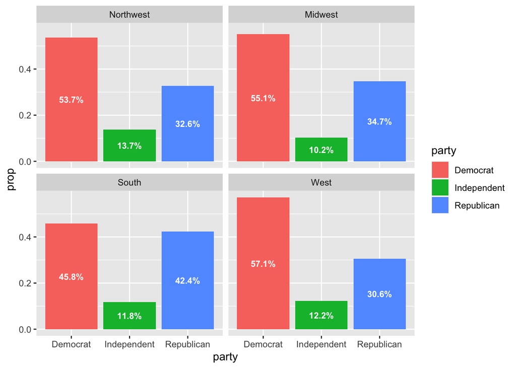

```r
summary %>%
  ggplot(aes(x = party, y = prop, fill = party))+
  geom_bar(position = "dodge", # change it to dodged bar plot, otherwise, it is stacked by default
           stat = "identity")+
  facet_wrap(~region)+
  geom_text(aes(label = scales::percent(prop, accuracy = 0.1)),
            size = 3,
            position = position_stack(vjust = 0.5), # change the position of text
            col = "white",
            fontface = "bold") # remember to change the font, you need to use fontface
```

[figure not shown]

```r
summary %>%
  ggplot(aes(x = reorder(party, -prop), y = prop, fill = party))+
  geom_bar(position = "dodge", # change it to dodged bar plot, otherwise, it is stacked by default
           stat = "identity",
           show.legend = FALSE)+
  facet_wrap(~region)+
  geom_text(aes(label = scales::percent(prop, accuracy = 0.1)),
            size = 3,
            position = position_stack(vjust = 0.5), # change the position text, this applies to each bar so use position_stack
            col = "white",
            fontface = "bold")+ # remember to change the font, you need to use fontface
  scale_fill_manual(values = c("#0000FF", "#FED105", "#FF0803"))+
  scale_y_continuous("Proportion",
                     limits = c(0, 0.6),
                     labels = scales::percent)+
  scale_x_discrete(labels = c("Democrat/len Dem.", "Independent", "Republican/len.Rep."))+
  labs(title = "Respondents' Party Affiliation by Region",
       caption = "Source: Cooperative Congressional Election Study 2019")+
  theme_fivethirtyeight()+
  theme(plot.title = element_text(size = 10, face = "bold", hjust = 0.5))
```

How this plot matches the real research conducted by research centers or think tanks? I didn’t find similar data visualization, but I do find some research conducted by [Gallup Poll](https://news.gallup.com/poll/15370/party-affiliation.aspx) and [Gallup Poll: 2017 U.S. Party Affiliation by State](https://news.gallup.com/poll/226643/2017-party-affiliation-state.aspx). If you are interested, you can read those articles.

#### 2.4 Scatter Plot with Text Labels

**Example**: Bubble Chart (Scatter Plot) of GDP Per Capita vs. Life Expectancy in 2007.

```r
# filter out 2007 data as a sample
gapminder_subset <- gapminder %>%
  filter(year == 2007)
```

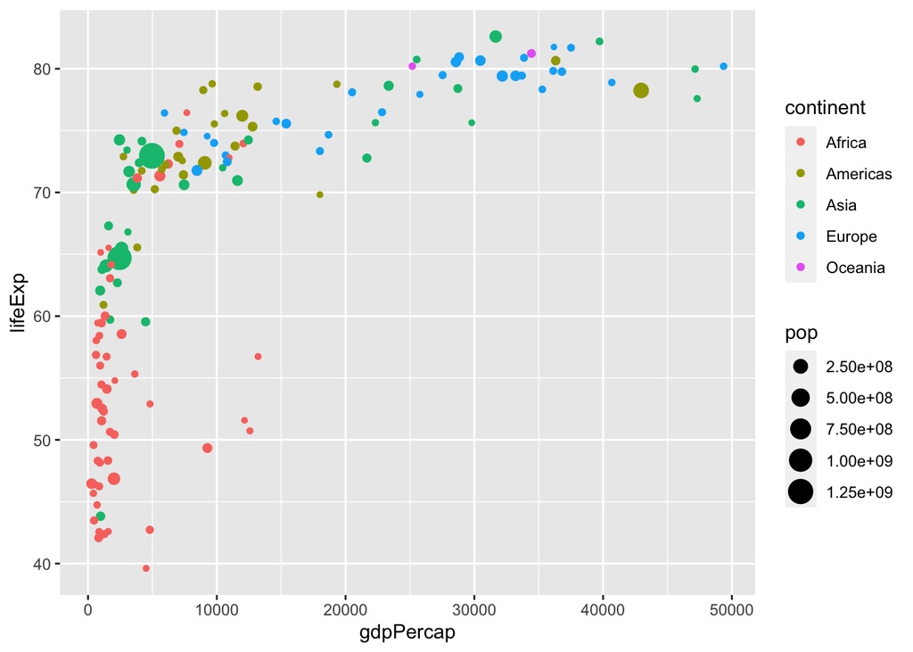

```r
gapminder_subset %>%
  ggplot(aes(x = gdpPercap, y = lifeExp, size = pop, col = continent))+
  geom_point()
```

- change axis scales, especially for x-axis, you can use `scale_x_log10` to change it into log scales. But I do not usually recommend people do log-transformation, because not every reader understand log transformation.
- change the size of points. We have very small points in the above plot. You can customize size use `scale_size_continuous`
- Customizing colors (try to play with `RColorBrewer`), color transparency (`alpha`).
- Select some countries that you are interested in add text labels to those countries so that readers know where they are.
- Add titles, caption, change axis tests, themes, and etc.

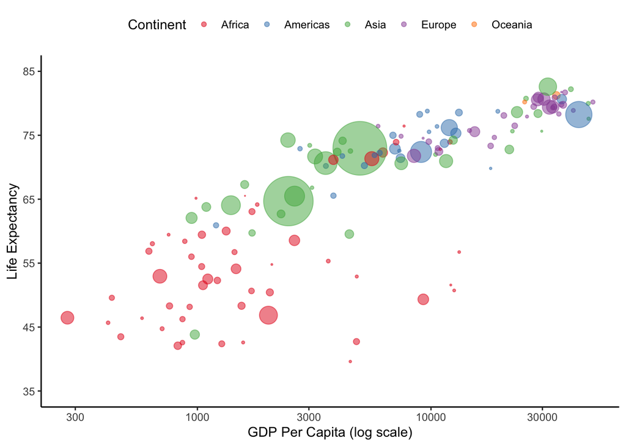

```r
gapminder_subset %>%
  ggplot(aes(x = gdpPercap, y = lifeExp, size = pop, col = continent))+
  geom_point(alpha = 0.5)+
  scale_size_continuous(range = c(0.1, 20))+ # customize the size of point
  scale_color_brewer(palette = "Set1")+
  scale_x_continuous(name = "GDP Per Capita (log scale)",
                     trans = "log10")+
  scale_y_continuous(name = "Life Expectancy",
                     limits = c(35, 85),
                     breaks = seq(35, 85, 10))+
  guides(size = FALSE,
         col = guide_legend(title = "Continent"))+
  theme_classic()+
  theme(legend.position = "top")
```

**Adding some text labels**

See what happens here

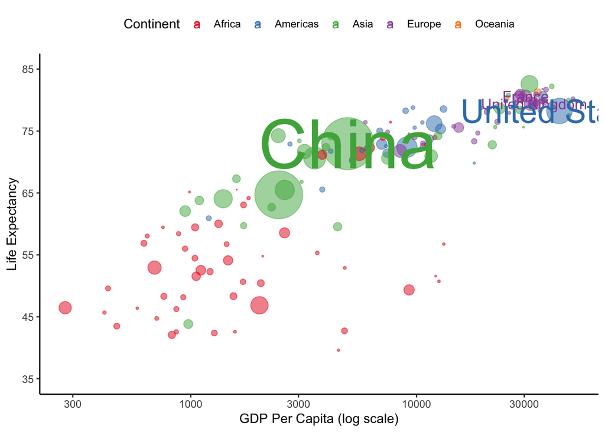

```r
gapminder_subset %>%
  ggplot(aes(x = gdpPercap, y = lifeExp, size = pop, col = continent))+
  geom_point(alpha = 0.5)+
  geom_text(data = gapminder_subset %>% filter(country %in% c("United States", "United Kingdom", "France", "China")),
            aes(label = country))+ # we have to subset again to label out some specific countries
  scale_size_continuous(range = c(0.1, 20))+
  scale_color_brewer(palette = "Set1")+
  scale_x_continuous(name = "GDP Per Capita (log scale)",
                     trans = "log10")+
  scale_y_continuous(name = "Life Expectancy",
                     limits = c(35, 85),
                     breaks = seq(35, 85, 10))+
  guides(size = FALSE,
         col = guide_legend(title = "Continent"))+
  theme_classic()+
  theme(legend.position = "top")
```

We can use `ggrepel` package to adjust or spread text automatically for you.

```r
library(ggrepel) # an algorithm that could spread out your text labels
```

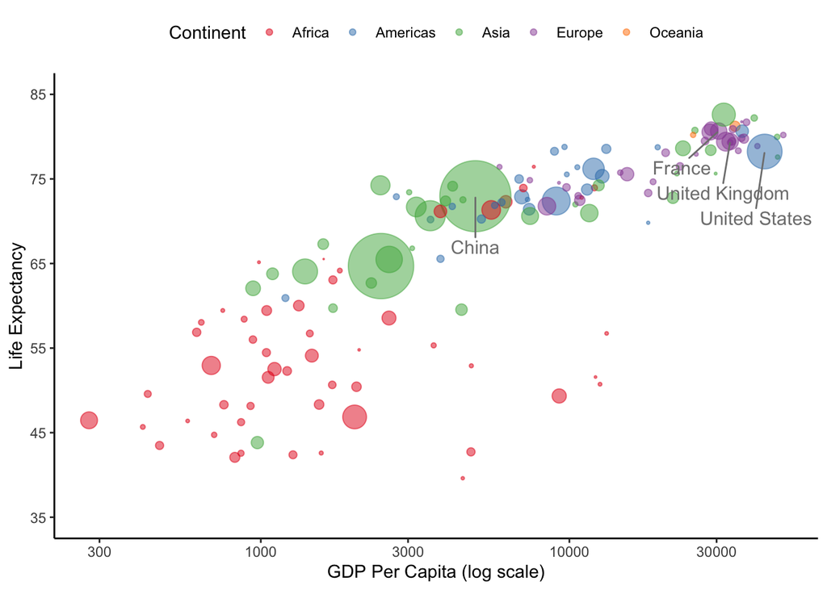

```r
p5 <- c("United States", "United Kingdom", "France", "China")
gapminder_subset %>%
  ggplot(aes(x = gdpPercap, y = lifeExp, size = pop, col = continent))+
  geom_point(alpha = 0.5)+
  geom_text_repel(data = gapminder_subset %>% filter(country %in% p5),
            aes(label = country),
            size = 4,
            col = "gray50",
            # use min.segment.length to draw all line segments, no matter how short they are
            min.segment.length = 0,
            # vertical adjustment or horizontal adjustment to nudge labels
            nudge_y = -6)+
  scale_size_continuous(range = c(0.1, 20))+
  scale_color_brewer(palette = "Set1")+
  scale_x_continuous(name = "GDP Per Capita (log scale)",
                     trans = "log10")+
  scale_y_continuous(name = "Life Expectancy",
                     limits = c(35, 85),
                     breaks = seq(35, 85, 10))+
  guides(size = FALSE,
         col = guide_legend(title = "Continent"))+
  theme_classic()+
  theme(legend.position = "top")
```

#### 2.5 Line Chart

**Example**: Visualize the Party Polarization over Congress

I am using a new dataset from the Center for Effective Law Making, a research project spearheaded by Craig Volden (Professor of Public Policy and Politics, University of Virginia) and Alan E. Wiseman (Professor of Political Science and Law, Vanderbilt University). Similar to CCES data, I have modified these data and if you want to do real research, you should download the original data files from the [Center for Effective Lawmaking](https://thelawmakers.org/data-download) website and review its codebook (Volden and Wiseman 2014). Here, I am using the US Congress (93rd-115th, 1973-2018) Legislative Effectiveness Data as an example.

```r
house <- read_csv("../data/cel_volden_wiseman.csv")
str(house)
```

[output not shown]

What I am doing here is to calculate each party’s mean DW-NOMINATE score for very congress. First, let’s generate a new variable as `party`, which indicates the party affiliation for each congressman or congresswoman in our dataset.

[output not shown]

**Finalize the plot**

[figure not shown]

```r
summary_dw %>%
  # you can choose to change congress either as integer or a factor, or you can use year as x variable
  ggplot(aes(x = as.integer(congress), y = ideology, col = party))+
  geom_line(aes(group = party),
            size = 1)+
  scale_color_manual(values = c("blue", "red"),
                     breaks = c("Democrat", "Republican"))+
  scale_x_continuous(limits = c(93, 115),
                     breaks = seq(93, 115, by = 2))+
  # If you want to manually add text labels
  geom_text(label = "Democratic Party", x = 111, y = 0.4, col = "blue")+
  geom_text(label = "Republican Party", x= 111, y = -0.25, col = "red")+
  geom_vline(xintercept = c(111, 114), linetype = "dashed")+
  geom_text(label = "Barack Obama", x= 112.5, y = 0.1, col = "black", size =2.8)+
  labs(title = "Party Polarization 93rd Congress - 115th Congress",
       caption = "Source: Center for Effective Lawmaking")+
  theme_fivethirtyeight()+
  guides(color = FALSE)+
  theme(plot.title = element_text(size = 10, face = "bold"))
```

Density plot may be more appropriate to show the polarization of U.S House over time. As you could see from the plot, the distribution of members of the two parties overlap less and less over time. This is an outcome that a lot of people connect to the intense partisan polarization that we could observe in American politics today, as the Democratic Party and Republican Party had become farther apart with less overlap. (I am not going to show you how to make this graph because it requires additional packages, but if you are interested in this, come to my office hour.)

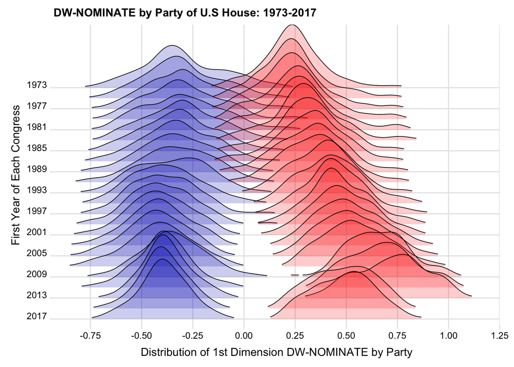

Our aim is to do some data visualizations, but always remember to help your readers to understand intentions or messages you want to send or present. And, most importantly, choose right graph!

#### 2.6 Dumbbell Chart (An alternative to grouped barcharts)

Dumbbell Chart is especially useful when you want to compare two points in a series that are on the same axis. For example, you can compare two points from different times, different test scores (to see if there exists an improvement after traning), or from two different groups.

**Task**: Referring back to `gapminder` dataset, suppose you want to use dumbbell chart to show the top 10 countries that have the largest increase in Life Expectancy from 1952 to 2007.

**Traditional Way**

```r
data <- gapminder %>%
  filter(year %in% c(1952, 2007)) %>%
  dplyr::select(country, continent, year, lifeExp)# Notice we have a long data here, we need to transfer it into a wide format
data_wide <- spread(data, key = year, value = lifeExp)
names(data_wide) <- c("country", "continent", "y1952", "y2007") # change column name
head(data_wide)
```

```
## # A tibble: 6 x 4
##   country     continent y1952 y2007
##   <fct>       <fct>     <dbl> <dbl>
## 1 Afghanistan Asia       28.8  43.8
## 2 Albania     Europe     55.2  76.4
## 3 Algeria     Africa     43.1  72.3
## 4 Angola      Africa     30.0  42.7
## 5 Argentina   Americas   62.5  75.3
## 6 Australia   Oceania    69.1  81.2
```

```r
summary_lifeExp <- data_wide %>%
  mutate(difference = y2007-y1952) %>%
  arrange(desc(difference)) %>%
  top_n(10, wt = difference)
summary_lifeExp
```

```
## # A tibble: 10 x 5
##    country            continent y1952 y2007 difference
##    <fct>              <fct>     <dbl> <dbl>      <dbl>
##  1 Oman               Asia       37.6  75.6       38.1
##  2 Vietnam            Asia       40.4  74.2       33.8
##  3 Indonesia          Asia       37.5  70.6       33.2
##  4 Saudi Arabia       Asia       39.9  72.8       32.9
##  5 Libya              Africa     42.7  74.0       31.2
##  6 Korea, Rep.        Asia       47.5  78.6       31.2
##  7 Nicaragua          Americas   42.3  72.9       30.6
##  8 West Bank and Gaza Asia       43.2  73.4       30.3
##  9 Yemen, Rep.        Asia       32.5  62.7       30.2
## 10 Gambia             Africa     30    59.4       29.4
```

Let’s start plotting. + Use `geom_point` to plot two points that represents year 1952 and year 2007 for each country. You should use two layers instead of one. + Use `geom_segment` to draw the line that connects two points. + Cutomize colors, adjust titles, subtitles, captions use `theme`.

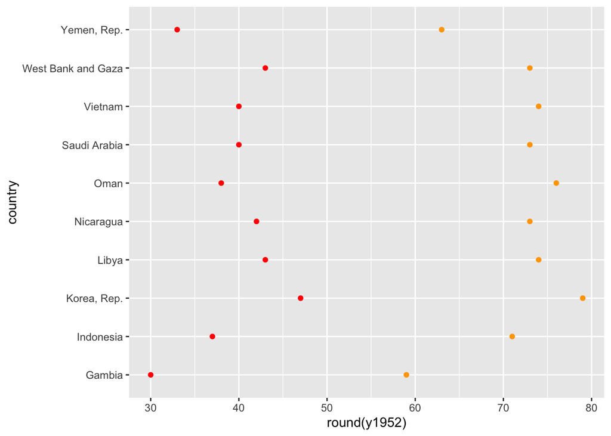

```r
summary_lifeExp %>%
  ggplot()+
  # Make sure you put col argument outside aesthetic mapping, otherwise, you will make mistakes
  geom_point(aes(x = round(y1952), y = country), col = "red")+
  geom_point(aes(x = round(y2007), y = country), col = "orange")
```

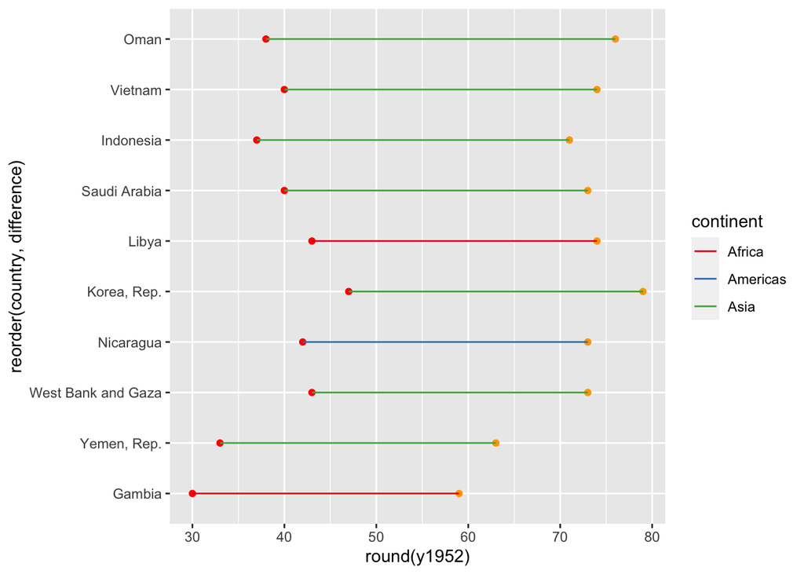

```r
summary_lifeExp %>%
  ggplot()+
  # Notice I use a reorder command for y
  geom_point(aes(x = round(y1952), y = reorder(country, difference)), col = "red")+
  geom_point(aes(x = round(y2007), y = country), col = "orange")+
  # Add lines to connect two points
  geom_segment(aes(x = round(y1952), xend = round(y2007),
                   y = country, yend = country,
                   col = continent))+
                   # here, I am putting color argument within aesthetic mapping,
                   # so each line will have different colors to represent different continents))
  scale_color_brewer(palette = "Set1") # R Color Brewer works for variable that within aesthetic mapping
```

Finalize the plot

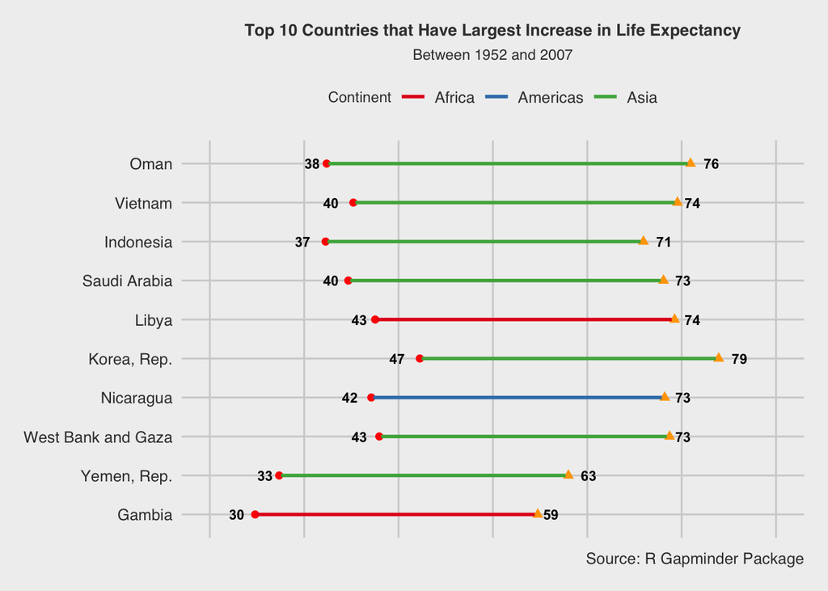

```r
summary_lifeExp %>%
  ggplot()+
  geom_point(aes(x = y1952-0.2, y = reorder(country, difference)), col = "red", shape = 16, size = 2)+
  geom_point(aes(x = y2007+0.3, y = country), col = "orange", shape = 17, size = 2)+
  geom_segment(aes(x = y1952, xend = y2007,
                   y = country, yend = country,
                   col = continent),
               size = 1)+
  scale_color_brewer(palette = "Set1")+
  geom_text(aes(x = round(y1952), y = country,
                label = round(y1952)),
            size = 3,
            fontface = "bold",
            hjust = 1.8)+
  geom_text(aes(x = round(y2007), y = country,
                label = round(y2007)),
            size = 3,
            fontface = "bold",
            hjust = -0.8)+
  scale_x_continuous(limits = c(25, 85),
                     breaks = seq(25, 85, by = 10))+
  labs(title = "Top 10 Countries that Have Largest Increase in Life Expectancy",
       subtitle = "Between 1952 and 2007",
       caption = "Source: R Gapminder Package")+
  theme_fivethirtyeight()+
  guides(col = guide_legend(title = "Continent"))+
  theme(plot.title = element_text(size = 10, face = "bold", hjust = 0.5),
        plot.subtitle = element_text(size = 9, hjust = 0.5),
        legend.position = "top",
        legend.title = element_text(size = 9),
        axis.text.x = element_blank())
```

Very complex right? Thanks to `ggalt` package, plotting this kind of plot could be very simple, you only need `geom_dumbbell` function to adding points, segments layers together.

```r
library(ggalt)
```

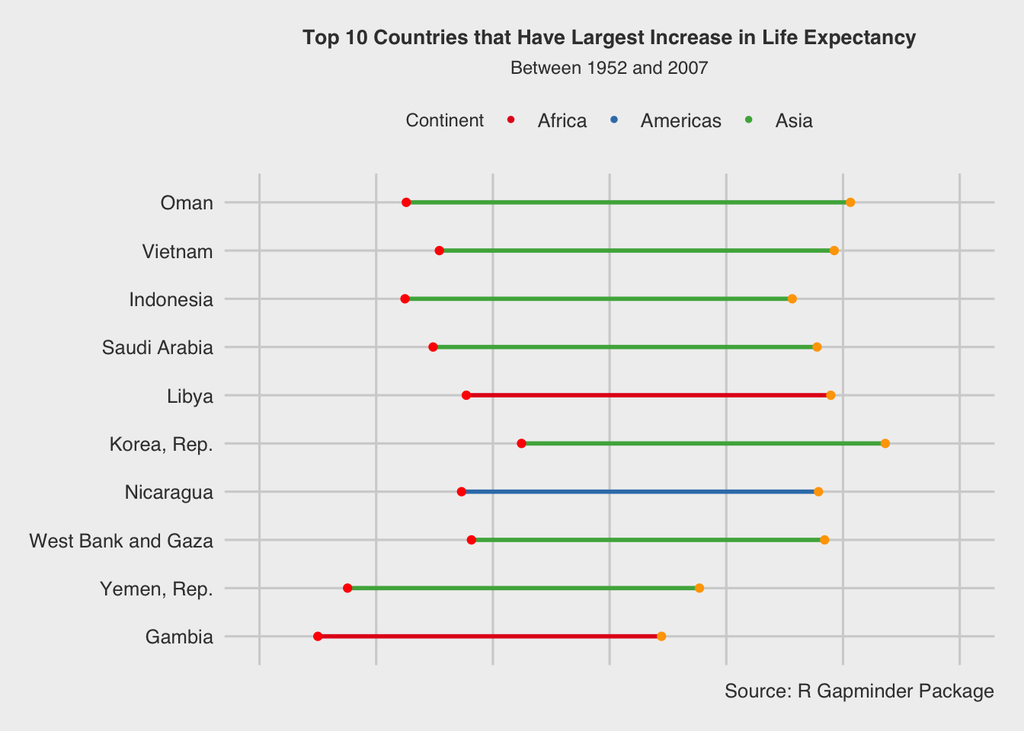

```r
summary_lifeExp %>%
  ggplot(aes(x = y1952, xend = y2007, y = reorder(country, difference), col = continent))+
  geom_dumbbell(colour_x = "red", # the colour of the start point. Notice: there is no US `color` for this package
                colour_xend = "orange", # the colour of the end point. Notice: there is no US `color` for this package
                size_x = 1.5, # the size of the start point
                size_xend = 1.5, # the size of the end point
                size = 1, # size for line width
                )+
  scale_color_brewer(palette = "Set1")+
  scale_x_continuous(limits = c(25, 85),
                     breaks = seq(25, 85, by = 10))+
  labs(title = "Top 10 Countries that Have Largest Increase in Life Expectancy",
       subtitle = "Between 1952 and 2007",
       caption = "Source: R Gapminder Package")+
  theme_fivethirtyeight()+
  guides(col = guide_legend(title = "Continent"))+
  theme(plot.title = element_text(size = 10, face = "bold", hjust = 0.5),
        plot.subtitle = element_text(size = 9, hjust = 0.5),
        legend.position = "top",
        legend.title = element_text(size = 9),
        axis.text.x = element_blank())
```

However, every package has its own limitations. You should try to learn both methods. To be specific, if you look back to the plot, we do have issues when deal with legends. For instance, what if I want to add legends for the shape of points?

#### Optional

**Task**: Add an additional legend to specify the year of point.

**Hint**: Consider how we change the shape of points in Base R plot command?

Here is an example of outcome. Come to my office hours if you want to know how to solve this issue:

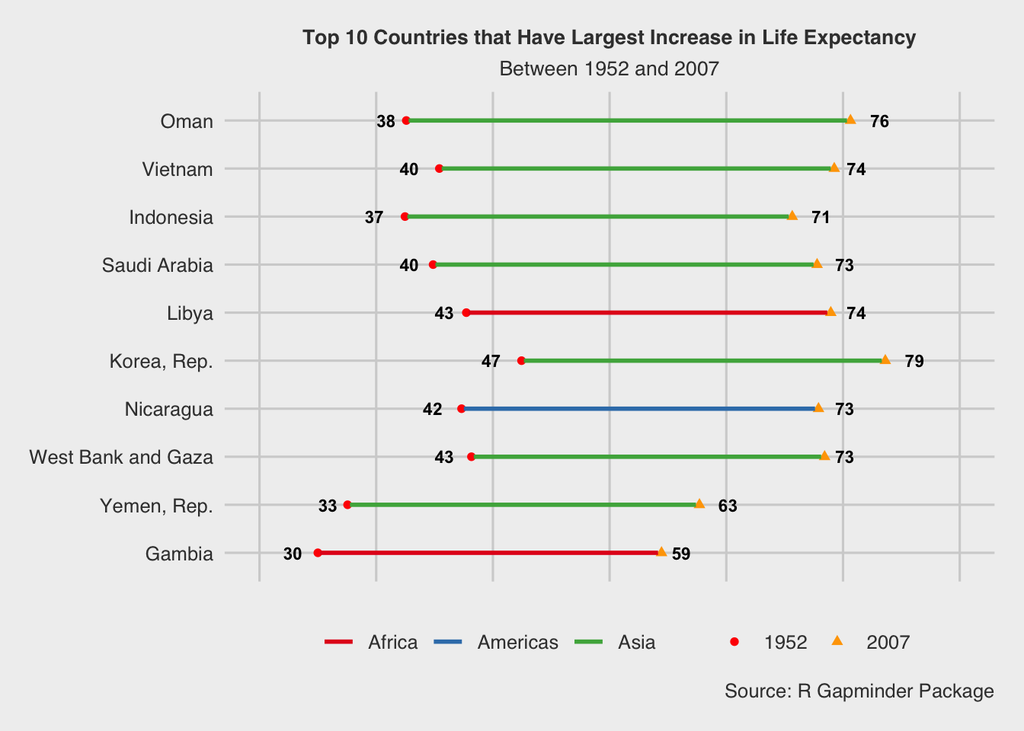

#### Reference

Ansolabehere, Stephen, Brian Schaffner, and Samantha Luks. 2020. “CCES Common Content, 2019.” Harvard Dataverse. https://doi.org/10.7910/DVN/WOT7O8.

Volden, Craig, and Alan E. Wiseman. 2014. *Legislative Effectiveness in the United States Congress: The Lawmakers*. Cambridge University Press. https://doi.org/10.1017/CBO9781139032360.